# Tests de Normalidad

Agustín Castro

2023-10-21

# Inicio

Píldoras_R. Material de formación

En esta práctica trabajemos con varias pruebas y gráficas para determinar si existe normalidad en los datos.

[mi_blog] https://agustincastro.es

# Librerías

Estas son las librerías que vamos a utilizar en esta práctica. Recuerda que sino las tienes, tendrás que instalarlas primero con **install.packages()** y, después, cargarlas en memoria con **library()**

```r
library(tidyverse)
library(tseries) # para test de Jarque-Bera
library(nortest) # para test de Lilliefors
library(car) # para los gráficos qqPlot con IC.
```

# Distribución normal

La distribución normal, también conocida como **gaussiana**, es una de las distribuciones más importantes en estadística y se caracteriza por **su forma de campana** y propiedades matemáticas bien definidas.

- **Forma de campana**: La distribución normal tiene una forma de **campana simétrica alrededor de su media**. A agruparse la mayoría de los valores alrededor de la media, la **mediana** y la **moda** son aproximadamente iguales.
- **Simetría**: La distribución normal es **simétrica alrededor de su media**. Esto indica que las colas de la distribución se extienden hacia los valores positivos y negativos de manera similar, lo que implica que hay igual probabilidad de observar valores por encima y por debajo de la media.
- **Parámetros específicos**: Una distribución normal está completamente definida por su media y su desviación estándar. La **media** determina el **centro de la distribución** y la **desviación estándar** determina la **dispersión** de los datos alrededor de la media.
- **Regla empírica**: La distribución normal sigue la regla empírica, que establece que alrededor del 68% de los datos se encuentran dentro de una desviación estándar de la media, alrededor del 95% dentro de dos desviaciones estándar y casi el 99.7% dentro de tres desviaciones estándar.
- **Función de densidad de probabilidad específica**: La función de densidad de probabilidad de una distribución normal está definida matemáticamente por la ecuación de la campana de Gauss.

## Tests de Normalidad

Las **pruebas de normalidad** en estadística son métodos utilizados para determinar si un conjunto de datos se distribuye normalmente o no.

La **verificación de la normalidad de los datos es fundamental en muchos análisis estadísticos y pruebas de hipótesis**. Algunos de los métodos comunes para probar la normalidad incluyen:

- **Prueba de Kolmogorov-Smirnov**: Esta prueba compara la distribución de los datos con una distribución normal teórica. Evalúa si la muestra tiene la misma distribución que una distribución normal específica.Esta prueba es útil cuando se tienen **muestras grandes (n > 50)** y no se dispone de información previa sobre la distribución de los datos.
- **Prueba de Shapiro-Wilk**: Esta prueba también se utiliza para evaluar si una muestra proviene de una población con distribución normal. Esta prueba es **más adecuada para muestras pequeñas (n < 50)** y es sensible a la detección de desviaciones de la normalidad en las colas de la distribución.
- **Prueba de Lilliefors**: Similar a la prueba de Kolmogorov-Smirnov, pero se recomienda especialmente para tamaños de muestra pequeños debido a sus ajustes para tamaños de muestra más reducidos.
- **Prueba de Jarque-Bera**: Esta prueba se utiliza para evaluar la normalidad basándose en la **asimetría** y la **curtosis** de los datos. Es útil cuando se sospecha que los datos pueden no seguir una distribución normal debido a desviaciones en estos dos parámetros.
- **Prueba de Anderson-Darling**: Esta prueba es una medida de la bondad de ajuste de un conjunto de datos a una distribución particular, como la distribución normal.Esta prueba es útil cuando se busca una evaluación detallada de la bondad de ajuste de los datos a una distribución normal. Es más efectiva en la detección de desviaciones en las colas de la distribución.

Es importante recordar que ninguna de estas pruebas puede demostrar con certeza que un conjunto de datos proviene de una distribución normal. En lugar de eso,…

- estas pruebas proporcionan una indicación de la **probabilidad** de que los datos puedan provenir de una distribución normal.
- Además, es **crucial** considerar el **tamaño de la muestra**.

# Dataset Iris

**iris** es un conjunto de datos incorporado en el entorno de R de forma predeterminada. Este contiene información sobre diferentes medidas de las flores de 3 especies del género iris (*Iris setosa*, *I. versicolor*, e *I. virginica*), como la longitud y el ancho de los pétalos y sépalos. Estos datos son muy utilizados en la enseñanza y práctica de análisis estadístico y aprendizaje automático en R.

Iris cuenta con 150 observaciones, para 5 variables y las 3 especies de Iris. Cada una de estas especies tiene 50 observaciones.

```r
str(iris)
```

```
## 'data.frame':    150 obs. of  5 variables:
##  $ Sepal.Length: num  5.1 4.9 4.7 4.6 5 5.4 4.6 5 4.4 4.9 ...
##  $ Sepal.Width : num  3.5 3 3.2 3.1 3.6 3.9 3.4 3.4 2.9 3.1 ...
##  $ Petal.Length: num  1.4 1.4 1.3 1.5 1.4 1.7 1.4 1.5 1.4 1.5 ...
##  $ Petal.Width : num  0.2 0.2 0.2 0.2 0.2 0.4 0.3 0.2 0.2 0.1 ...
##  $ Species     : Factor w/ 3 levels "setosa","versicolor",..: 1 1 1 1 1 1 1 1 1 1 ...
```

```r
head(iris, 10)
```

|  | Sepal.Length | Sepal.Width | Petal.Length | Petal.Width | Species |
| --- | --- | --- | --- | --- | --- |
| 1 | 5.1 | 3.5 | 1.4 | 0.2 | setosa |
| 2 | 4.9 | 3.0 | 1.4 | 0.2 | setosa |
| 3 | 4.7 | 3.2 | 1.3 | 0.2 | setosa |
| 4 | 4.6 | 3.1 | 1.5 | 0.2 | setosa |
| 5 | 5.0 | 3.6 | 1.4 | 0.2 | setosa |
| 6 | 5.4 | 3.9 | 1.7 | 0.4 | setosa |
| 7 | 4.6 | 3.4 | 1.4 | 0.3 | setosa |
| 8 | 5.0 | 3.4 | 1.5 | 0.2 | setosa |
| 9 | 4.4 | 2.9 | 1.4 | 0.2 | setosa |
| 10 | 4.9 | 3.1 | 1.5 | 0.1 | setosa |

```r
unique(iris$Species)
```

```
## [1] setosa     versicolor virginica
## Levels: setosa versicolor virginica
```

```r
# 50 observaciones para cada especie, por ejemplo:
sum(iris$Species == "setosa")
```

```
## [1] 50
```

# Gráficos para el análisis

## Histogramas

Nos vamos a fijar ahora en las medidas de la longitud de los pétalos y sépalos, sin diferenciar entre las especies, y vamos a representar gráficamente los histogramas de estas medidas. Observando gráficamente los datos podemos hacernos una idea de si estos se distribuirían de forma normal o, por el contrario, se alejan de esta distribución.

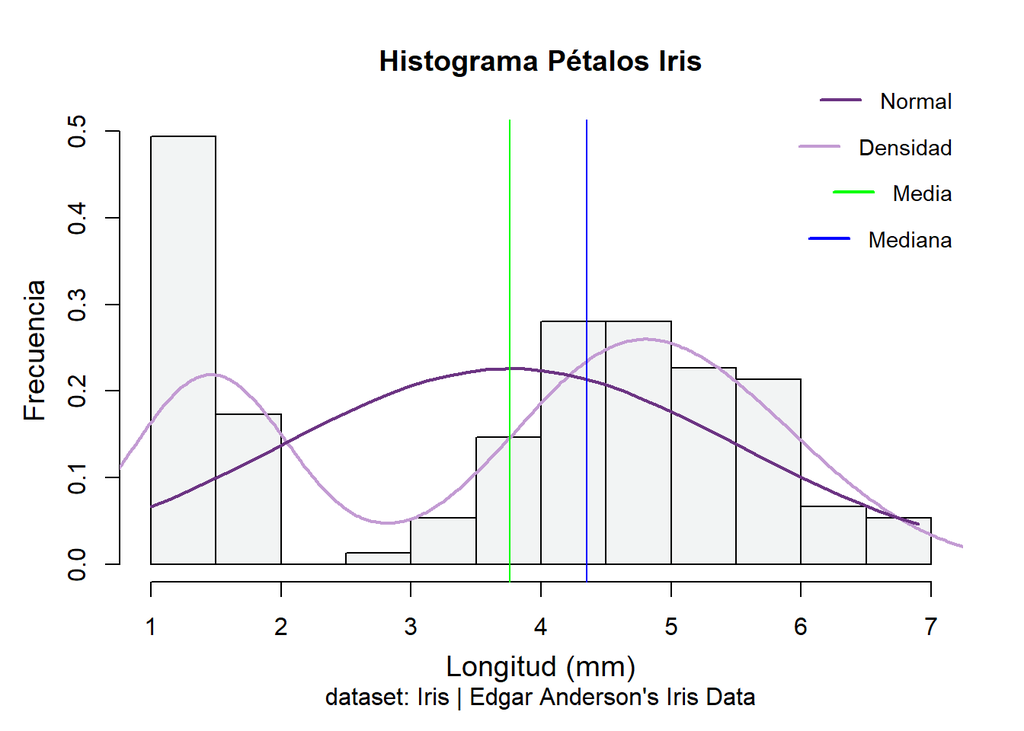

```r
hist(iris$Petal.Length,
     prob = TRUE,
     main = "Histograma Pétalos Iris",
     sub = "dataset: Iris | Edgar Anderson's Iris Data",
     xlab = "Longitud (mm)",
     ylab = "Frecuencia",
     cex.lab = 1.2,
     cex.axis = 1,
     mgp = c(2.4, 1, 0),
     col = "#F2F4F4")
lines(density(iris$Petal.Length), lwd = 2, col = '#C39BD3')
x <- seq(min(iris$Petal.Length), max(iris$Petal.Length), length = 40)
f <- dnorm(x, mean = mean(iris$Petal.Length), sd = sd(iris$Petal.Length))
lines(x, f, col = "#6C3483", lwd = 2) # Normal
abline(v=median(iris$Petal.Length), col="blue")
abline(v=mean(iris$Petal.Length), col="green")
legend("topright", legend = "Densidad", col = "#C39BD3",
       lty = 1, lwd = 2, bty = "n", cex = 0.9)
legend("topright", legend = "Normal", col = "#6C3483",
       lty = 1, lwd = 2, bty = "n", cex = 0.9, inset = c(0, -0.1), xpd = TRUE)
legend("topright", legend = "Media", col = "green",
       lty = 1, lwd = 2, bty = "n", cex = 0.9, inset = c(0, 0.1), xpd = TRUE)
legend("topright", legend = "Mediana", col = "blue",
       lty = 1, lwd = 2, bty = "n", cex = 0.9, inset = c(0, 0.2), xpd = TRUE)
```

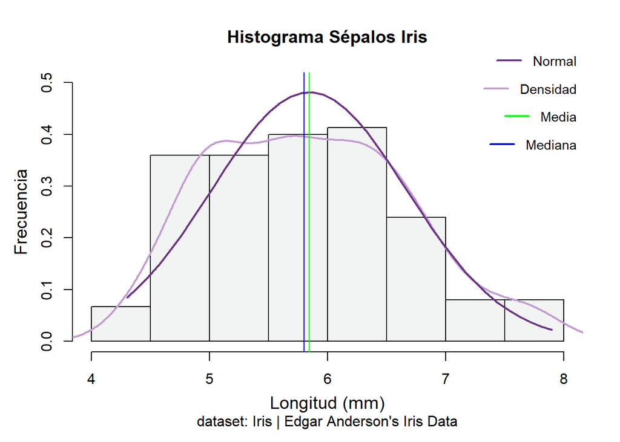

```r
hist(iris$Sepal.Length,
     prob = TRUE,
     main = "Histograma Sépalos Iris",
     sub = "dataset: Iris | Edgar Anderson's Iris Data",
     xlab = "Longitud (mm)",
     ylab = "Frecuencia",
     cex.lab = 1.2,
     cex.axis = 1,
     ylim = c(0, 0.50),
     mgp = c(2.4, 1, 0),
     col = "#F2F4F4")
lines(density(iris$Sepal.Length), lwd = 2, col = '#C39BD3')
x <- seq(min(iris$Sepal.Length), max(iris$Sepal.Length), length = 40)
f <- dnorm(x, mean = mean(iris$Sepal.Length), sd = sd(iris$Sepal.Length))
lines(x, f, col = "#6C3483", lwd = 2) # Normal
abline(v=median(iris$Sepal.Length), col="blue")
abline(v=mean(iris$Sepal.Length), col="green")
legend("topright", legend = "Densidad", col = "#C39BD3",
       lty = 1, lwd = 2, bty = "n", cex = 0.9)
legend("topright", legend = "Normal", col = "#6C3483",
       lty = 1, lwd = 2, bty = "n", cex = 0.9, inset = c(0, -0.1), xpd = TRUE)
legend("topright", legend = "Media", col = "green",
       lty = 1, lwd = 2, bty = "n", cex = 0.9, inset = c(0, 0.1), xpd = TRUE)
legend("topright", legend = "Mediana", col = "blue",
       lty = 1, lwd = 2, bty = "n", cex = 0.9, inset = c(0, 0.2), xpd = TRUE)
```

## Diagrama QQ

Un **diagrama QQ (quantile-quantile)** es una representación gráfica que se utiliza para **comparar la distribución de probabilidades de dos conjuntos de datos**. En el eje horizontal se representan los cuantiles teóricos esperados de una distribución específica (generalmente la distribución normal), mientras que en el eje vertical se representan los cuantiles observados de los datos reales que se están analizando.

Al comparar la distribución teórica con la distribución real de los datos en el gráfico, se puede determinar si ambas distribuciones siguen un patrón similar. **Si los puntos en el gráfico caen aproximadamente a lo largo de una línea diagonal, esto sugiere que los datos siguen la distribución teórica asumida**. Por otro lado, si los puntos se desvían significativamente de la línea diagonal, indica que los datos no se ajustan bien a la distribución teórica asumida.

En este caso, el gráfico muestra que los datos de **longitud de los pétalos** de las especies del Gen. Iris analizadas, no siguen una distribución normal.

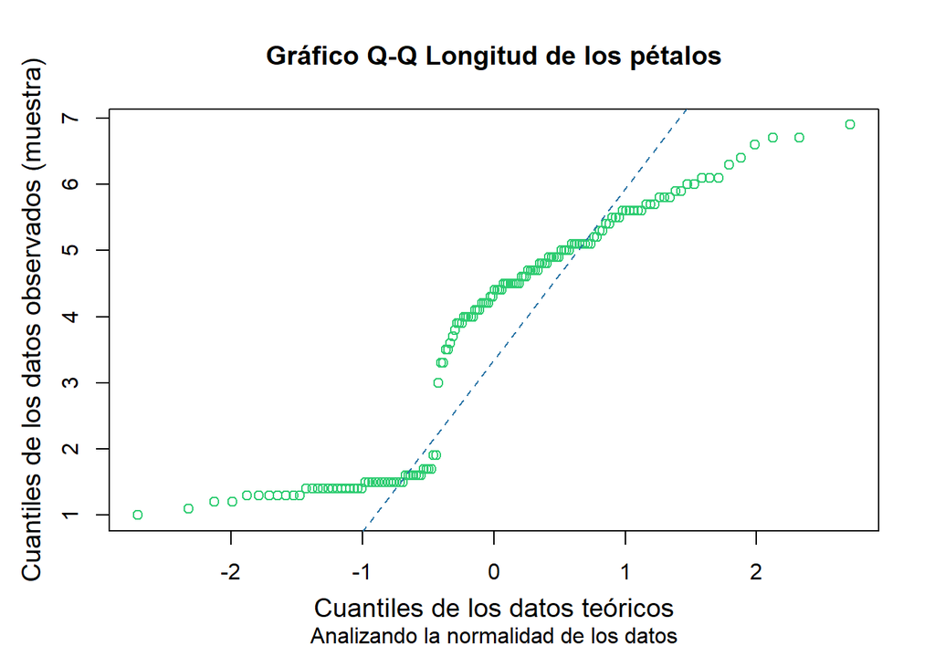

```r
qqnorm(iris$Petal.Length,
       main = "Gráfico Q-Q Longitud de los pétalos",
       sub = "Analizando la normalidad de los datos",
       xlab = "Cuantiles de los datos teóricos",
       ylab = "Cuantiles de los datos observados (muestra)",
       cex.lab = 1.2,
       cex.axis = 1,
       mgp = c(2.4, 1, 0),
       col = "#2ECC71")
qqline(iris$Petal.Length,
       col = "#2874A6",
       lty = 2,
       lwd = 1)
```

En este otro caso, la **longitud de los sépalos** de las tres especies de Iris estudiadas presentan una distribución que se ajusta a la normal, o gaussiana.

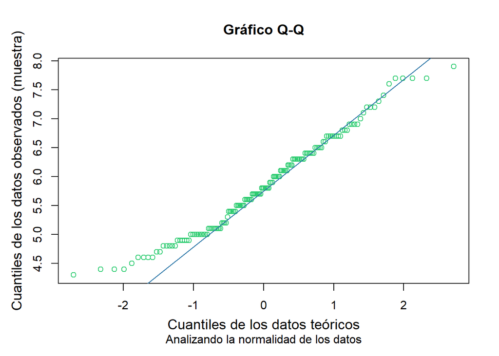

```r
qqnorm(iris$Sepal.Length,
       main = "Gráfico Q-Q",
       sub = "Analizando la normalidad de los datos",
       xlab = "Cuantiles de los datos teóricos",
       ylab = "Cuantiles de los datos observados (muestra)",
       cex.lab = 1.2,
       cex.axis = 1,
       mgp = c(2.4, 1, 0),
       col = "#2ECC71")
qqline(iris$Sepal.Length,
       col = "#2874A6",
       lty = 1,
       lwd = 1)
```

También podemos realizar este otro gráfico con la función **qqPlot** de la librería **car**. Con esta función podemos mostrar el intervalo de confianza del 95%, lo que indicaría que el gráfico Q-Q muestra un envelope alrededor de la línea diagonal que cubre el 95% de los puntos si los datos se ajustan a la distribución teórica especificada (normal en este caso, indicado en distribution = “norm”).

Con la función qqPlot de cars es posible indicar con qué distribución comparamos el ajuste de los datos y, que se muestre el intervalo de confianza que indiquemos. Es posible, por ejemplo, calcularlo para un 99%, en vez del 95%.

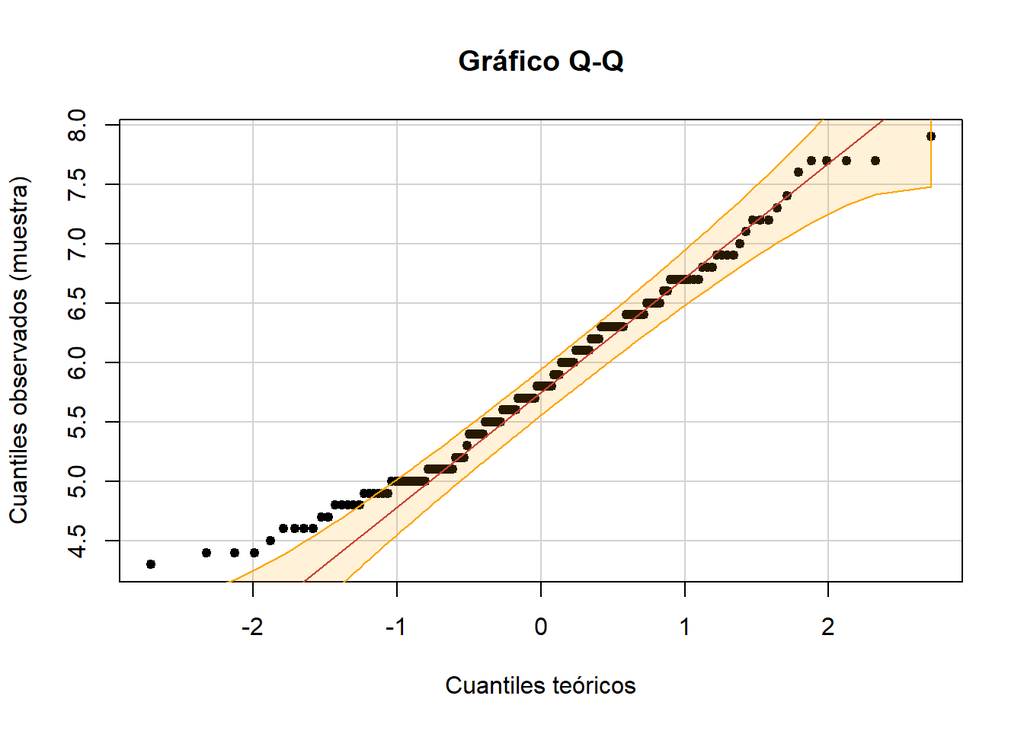

```r
qqPlot(iris$Sepal.Length,
       distribution = "norm",
       main = "Gráfico Q-Q",
       xlab = "Cuantiles teóricos",
       ylab = "Cuantiles observados (muestra)",
       envelope = 0.95, col=carPalette()[1], col.lines = carPalette()[5],
       line=c("quartiles", "robust", "none"),
       id = FALSE, grid = TRUE,
       pch = 19,
       cex = 0.8,
       lwd = 1)
# si quieres puedes poner encima la línea media con qqline
qqline(iris$Sepal.Length,
       col = "#CB4335",
       lty = 1,
       lwd = 1)
```

# Tests de normalidad

## Kolmogorov-Smirnov

Vamos a calcular el test de KS a las variables **longitud de los pétalos** y **sépalos** de las especies del Gen. Iris. **El número de observaciones es de 150** (condición necesaria para que pueda realizarse este test (n > 50)).

```r
length(iris$Petal.Length)
```

```
## [1] 150
```

```r
ks.test(iris$Petal.Length, "pnorm",
        mean = mean(iris$Petal.Length),
        sd = sd(iris$Petal.Length))
```

```
##
##  Asymptotic one-sample Kolmogorov-Smirnov test
##
## data:  iris$Petal.Length
## D = 0.19815, p-value = 1.532e-05
## alternative hypothesis: two-sided
```

```r
ks.test(iris$Sepal.Length, "pnorm",
        mean = mean(iris$Sepal.Length),
        sd = sd(iris$Sepal.Length))
```

```
##
##  Asymptotic one-sample Kolmogorov-Smirnov test
##
## data:  iris$Sepal.Length
## D = 0.088654, p-value = 0.1891
## alternative hypothesis: two-sided
```

Aquí un ejemplo de cálculo de los restantes test de normalidad mencionados en la práctica. Recordad que es neceario que se cumplan los supuestos necesarios para poder utilizarlos (ver descripción de los tests al comienzo del documento).

## Shapiro-Wilk

```r
shapiro.test(iris$Petal.Width)
```

```
##
##  Shapiro-Wilk normality test
##
## data:  iris$Petal.Width
## W = 0.90183, p-value = 1.68e-08
```

## Lilliefors

```r
lillie.test(iris$Petal.Length)
```

```
##
##  Lilliefors (Kolmogorov-Smirnov) normality test
##
## data:  iris$Petal.Length
## D = 0.19815, p-value = 7.901e-16
```

## Jarque-Bera

```r
jarque.bera.test(iris$Petal.Length)
```

```
##
##  Jarque Bera Test
##
## data:  iris$Petal.Length
## X-squared = 14.023, df = 2, p-value = 0.0009013
```

## Anderson-Darling

```r
ad.test(iris$Petal.Length)
```

```
##
##  Anderson-Darling normality test
##
## data:  iris$Petal.Length
## A = 7.6785, p-value < 2.2e-16
```

eof